# Data Wrangling with R Exercises

Dr. Laurie Baker

[figure not shown]

# 1 Course Overview

- **The Beginning**
  - Creating Projects in RStudio
  - Recap: Importing and Exporting Data
- **Tidying and quality checking**
  - tidying column names
  - missing data
  - removing duplicates
  - detecting outliers
- **Reshaping Data**
  - pivot_longer, pivot_wider
  - arranging data
  - unite and separate
- **Dates and times**
  - lubridate
  - time zones

## 1.1 For this adventure:

### 1.1.1 Packages

```r
#install.packages("tidyverse")
#install.packages("janitor")
#install.packages("visdat")
#install.packages("naniar")
#install.packages("lubridate")
#install.packages("haven")
#install.packages("readxl")

library(tidyverse)
library(janitor)
library(visdat)
library(naniar)
library(lubridate)
library(haven)
library(readxl)
```

### 1.1.2 Datasets

- `titanic`: fate of passengers on the fatal maiden voyage of the ocean liner ‘Titanic’.
- `police_data`: ONS UK Crime Data from 2013
- `gapminder`: Gapminder foundation
- `billboard`: Billboard music charts
- `relig_income`: Pew research
- `training_schedule`: Our training schedule:-).

## 1.2 Projects

- **‘New project…’** from the File menu, **‘New Directory’** to create a directory for the project.
- Future, select **‘Open Project…’** or **‘Recent Projects’** from the File menu.
- Benefit: your working directory will always be set to the project folder -> no need to worry about file paths.

### 1.2.1 File organisation

- **data** containing your raw and processed data.
- **images** containing photos you are using.
- **scripts** containing all the R script files.

## 1.3 Importing Data

Before importing your data you need to know,

- Where it is stored?
- What kind of file it is?
- Are there any missing values in the data (denoted by `na`).

### 1.3.1 File type

There are a variety of ways of reading data into R:

- `readr` - read csv, tsv
- `readxl` - excel, xlsx
- `haven` - SPSS, Stata and SAS files,
- `DBI` + `dplyr` or `dbplyr` - Databases,
- `jsonlite` - json files,
- `httr` - Web APIs,
- `rvest` - HTML (Web Scraping)

## 1.4 Reading in a csv

```r
path <- file.path("../data", "titanic.csv")

titanic <- readr::read_csv(file = path)
```

## 1.5 readxl

- Reads excel data into R (both `.xls` and `.xlsx`) formats.

```r
file_path <- file.path("../data", "police_data.xlsx")

police_data <- readxl::read_excel(path = file_path)
```

| Crime in England & Wales, year ending September 2013 - PFA tables |
| --- |
| NA |
| These data tables are published alongside the bulletin Crime in England & Wales, year ending September 2013 |
| NA |
| For explanatory notes on these statistics, see the User Guide to Crime Statistics for England and Wales |
| NA |
| Data tables shown in this workbook relate to police recorded crime. |
| NA |
| The data contained in this file comprise: |
| NA |
| Table P1: Police recorded crime by offence group and police force area, English regions and Wales, number of offences, 12 months to September 2013 |
| Table P2: Police recorded crime by offence group and police force area, English regions and Wales, percentage change, year ending September 2012 compared with year ending September 2013 |
| Table P3: Police recorded crime by offence group and police force area, English regions and Wales, rate of offences, 12 months to September 2013 |
| NA |
| For further information about police recorded crime statistics, please email crimestatistics@ons.gsi.gov.uk |
| or write to: Crime Statistics and Analysis, Office for National Statistics, 2nd Floor, 1 Drummond Gate, London, SW1V 2QQ |
| NA |
| Statistical contact: John Flatley |
| Tel: 020 7592 8695 |
| Email: crimestatistics@ons.gsi.gov.uk |

### 1.5.1 Dealing with multiple sheets

- the `excel_sheets()` function provides the names of the sheets without having to open the file.

```r
## To find out the excel sheet names from excel file

readxl::excel_sheets(file_path)
```

```
## [1] "Notes"    "Table P1" "Table P2" "Table P3"
```

### 1.5.2 Your Turn

1. Add an additional argument in the `read_excel` function to read in the second sheet (Table P1) from the police data.

```r
police_data <- read_excel(
  path = file_path,
  _______ = _______)
```

Hint: Look at the help documentation by typing in ?read_excel, is there an argument that talks about “sheet”?

### 1.5.3 Specifying a cell range

- To get rid of blank rows we can specify a cell range.

```r
police_data <- readxl::read_excel(path = file_path,
                                  sheet = 2,
                                  range = "A5:AA48")
```

## 1.6 SPSS and SAS with haven

```r
file_path <- file.path("folder", "file_name.sav")
read_spss(file_path)


file_path <- file.path("folder", "file_name.sas7bdat")
read_sas(file_path)
```

- After running `library(haven)` try `?read_sas` and `?read_spss` to find out more.

## 1.7 Exporting the Data

As an example we will export the police data we just imported.

```r
export_path <- file.path("../data", "test.csv")
readr::write_csv(police_data, path = export_path)
```

# 2 Tidying and quality-checking data

## 2.1 Tidying up names using `janitor`

```r
names(titanic)
```

```
##  [1] "Pclass"            "Survived"          "name Of Passenger"
##  [4] "Sex of passenger"  "Age of passenger"  "Sibsp"
##  [7] "Parch"             "Ticket"            "Fare"
## [10] "Cabin"             "Embarked"
```

```r
titanic <- janitor::clean_names(titanic)

names(titanic)
```

```
##  [1] "pclass"            "survived"          "name_of_passenger"
##  [4] "sex_of_passenger"  "age_of_passenger"  "sibsp"
##  [7] "parch"             "ticket"            "fare"
## [10] "cabin"             "embarked"
```

## 2.2 Missing Data

[figure not shown]

[output not shown]

[figure not shown]

```r
visdat::vis_dat(titanic)
```

### 2.2.1 How many are missing?

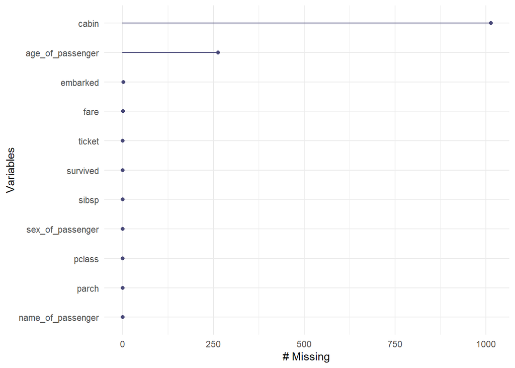

```r
naniar::gg_miss_var(titanic)
```

- Using `naniar` we can explore missing data further using functions like `gg_miss_var` that work with `ggplot`.

## 2.3 Exploring the mechanisms

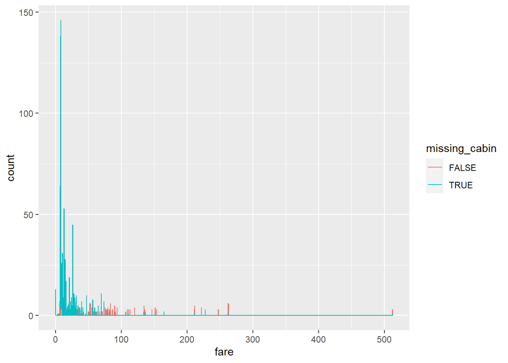

```r
titanic %>%
      mutate(
        missing_cabin = is.na(cabin)
      ) %>%
      ggplot(titanic, mapping = aes(fare)) +
        geom_freqpoly(aes(colour = missing_cabin),
                      binwidth = 1/4)
```

- Are we missing the cabin for certain fares more?
- Using `is.na()` to create a colour.

## 2.4 Prepping the gapminder data

- Load the gapminder data

```r
my_file <- file.path("../data", "gapminder.csv")

gapminder <- read_csv(file = my_file)
```

- clean it

```r
gapminder <- clean_names(gapminder)

names(gapminder)
```

```
## [1] "country"          "continent"        "year"             "life_exp"
## [5] "pop"              "gdp_percap"       "infant_mortality" "fertility"
```

- We can also change the column using `rename`. The form is `new_name = old_name`.

```r
gapminder %>%
  rename(population = pop) %>%
  head()
```

```
## # A tibble: 6 x 8
##   country continent  year life_exp population gdp_percap infant_mortality
##   <chr>   <chr>     <dbl>    <dbl>      <dbl>      <dbl>            <dbl>
## 1 Afghan~ Asia       1952     28.8    8425333       779.               NA
## 2 Afghan~ Asia       1957     30.3    9240934       821.               NA
## 3 Afghan~ Asia       1962     32.0   10267083       853.               NA
## 4 Afghan~ Asia       1967     34.0   11537966       836.               NA
## 5 Afghan~ Asia       1972     36.1   13079460       740.               NA
## 6 Afghan~ Asia       1977     38.4   14880372       786.               NA
## # ... with 1 more variable: fertility <dbl>
```

### 2.4.1 Explore missing data in gapminder

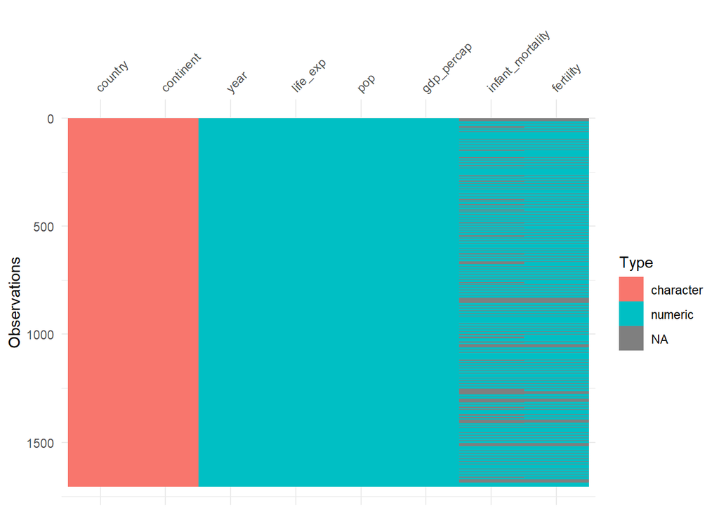

```r
visdat::vis_dat(gapminder)
```

### 2.4.2 The *missing* relationship

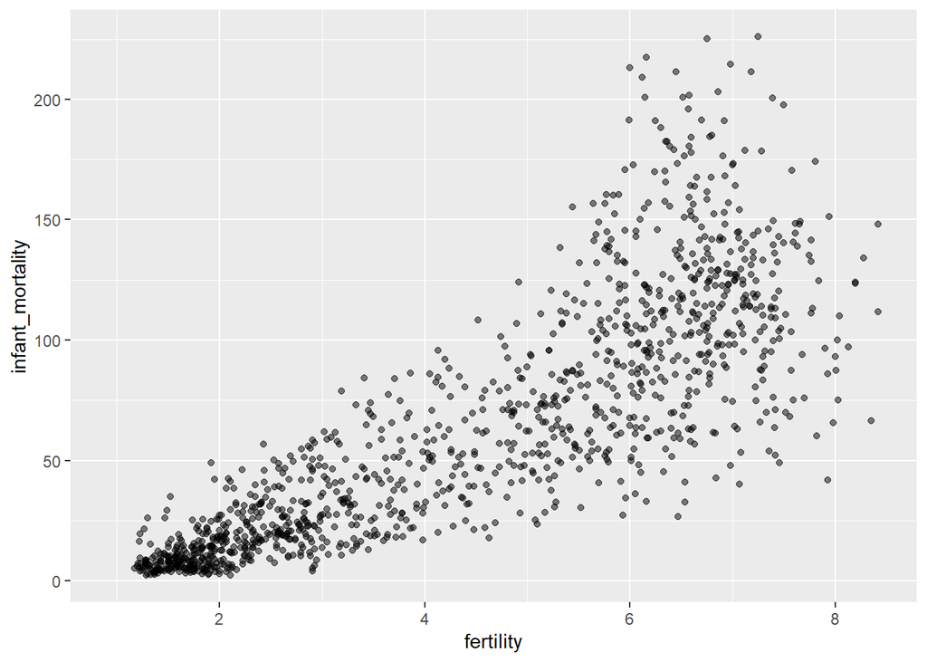

```r
ggplot(gapminder,
    aes(x = fertility,
        y = infant_mortality)) +
    geom_point(alpha = 0.5)
```

- By default, `ggplot` does not handle missing data.
- This makes it hard to explore and to know where data is missing.

### 2.4.3 Visualising something that’s not there

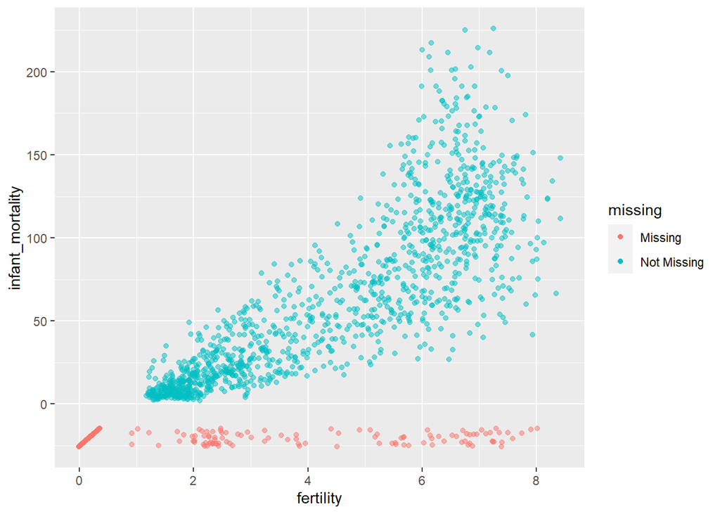

```r
ggplot(gapminder,
    aes(x = fertility,
        y = infant_mortality)) +
  geom_miss_point(alpha = 0.5) #<<
```

- Replace “NA” values with values 10% lower than the minimum value in that variable.

## 2.5 Missing data: exploring patterns

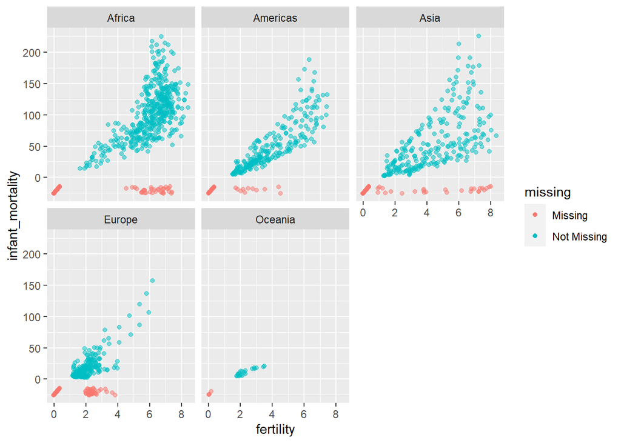

```r
ggplot(gapminder,
    aes(x = fertility,
        y = infant_mortality)) +
  geom_miss_point(alpha = 0.5) +
  facet_wrap(~continent) #<<
```

### 2.5.1 Your Turn

Fill in the blank to update the plot code to look at the year.

```r
ggplot(gapminder,
    aes(x = fertility,
        y = infant_mortality)) +
  geom_miss_point(alpha = 0.5) +
  facet_wrap(~_______)
```

## 2.6 Detecting unusual data

We can look at all the distinct values for a variable using the verb `distinct`.

```r
titanic %>%
  distinct(sibsp)
```

```
## # A tibble: 7 x 1
##   sibsp
##   <dbl>
## 1     0
## 2     1
## 3     2
## 4     3
## 5     4
## 6     5
## 7     8
```

This can help us identify anything unusual or also see what values come up.

For numeric variables we can use `summary` to get an idea of the spread of the data

```r
summary(titanic$fare)
```

```
##    Min. 1st Qu.  Median    Mean 3rd Qu.    Max.    NA's
##   0.000   7.896  14.454  33.295  31.275 512.329       1
```

Looking at the output of summary what is the maximum and minimum fare?

## 2.7 Replacing values

- Replacing values using the statement `case_when()`.

```r
titanic %>%
  mutate(survived =
           case_when(survived == 1 ~ "yes",
                     survived == 0 ~ "no")
         )
```

```
## # A tibble: 1,309 x 11
##    pclass survived name_of_passeng~ sex_of_passenger age_of_passenger sibsp
##     <dbl> <chr>    <chr>            <chr>            <chr>            <dbl>
##  1      1 yes      Allen, Miss. El~ female           29                   0
##  2      1 yes      Allison, Master~ male             0.9167               1
##  3      1 no       Allison, Miss. ~ female           2                    1
##  4      1 no       Allison, Mr. Hu~ male             30                   1
##  5      1 no       Allison, Mrs. H~ female           25                   1
##  6      1 yes      Anderson, Mr. H~ male             48                   0
##  7      1 yes      Andrews, Miss. ~ female           63                   1
##  8      1 no       Andrews, Mr. Th~ male             NULL                 0
##  9      1 yes      Appleton, Mrs. ~ female           NULL                 2
## 10      1 no       Artagaveytia, M~ male             NULL                 0
## # ... with 1,299 more rows, and 5 more variables: parch <dbl>, ticket <chr>,
## #   fare <dbl>, cabin <chr>, embarked <chr>
```

- `case_when()` is a two-sided formula where the left-hand side is a logical condition (yes or no) and the right-hand side is the value to assign when that test is `TRUE`, with the two sides separated by a `~`.
- We may use `case_when()` to create a `quality_check` column.

```r
titanic %>%
  mutate(quality_check = case_when(fare > 100 ~ "outlier",
                                   fare <= 100 ~ "keep",
                                    TRUE ~ "missing") #<<
        ) %>%
  select(quality_check)
```

```
## # A tibble: 1,309 x 1
##    quality_check
##    <chr>
##  1 outlier
##  2 outlier
##  3 outlier
##  4 outlier
##  5 outlier
##  6 keep
##  7 keep
##  8 keep
##  9 keep
## 10 keep
## # ... with 1,299 more rows
```

- Values not managed by the logical tests get a default replacement value: `NA`.
- If we prefer these values to not get an `NA` then we can use `TRUE ~ missing`
- We can do this by putting `TRUE` on the left hand side and the catch-all value on the right:

## 2.8 Detecting duplicates

- Caused by combining data, data entry mistakes.

```r
data(mtcars)

janitor::get_dupes(dat = mtcars, mpg, hp)
```

```
##   mpg  hp dupe_count cyl disp drat    wt  qsec vs am gear carb
## 1  21 110          2   6  160  3.9 2.620 16.46  0  1    4    4
## 2  21 110          2   6  160  3.9 2.875 17.02  0  1    4    4
```

```r
mtcars %>%
  get_dupes(wt)
```

```
##     wt dupe_count  mpg cyl  disp  hp drat  qsec vs am gear carb
## 1 3.44          3 18.7   8 360.0 175 3.15 17.02  0  0    3    2
## 2 3.44          3 19.2   6 167.6 123 3.92 18.30  1  0    4    4
## 3 3.44          3 17.8   6 167.6 123 3.92 18.90  1  0    4    4
## 4 3.57          2 14.3   8 360.0 245 3.21 15.84  0  0    3    4
## 5 3.57          2 15.0   8 301.0 335 3.54 14.60  0  1    5    8
```

Duplicates often creep into our datasets when we combine data from sources or can also accidentally occur during data entry.

Like other functions that follow `tidyverse` principles. We can also use this function with the pipe.

We can use the function `get_dupes` from the R package `janitor` to identify duplicates. We need to specify the data frame (`dat`) and then the variable combination to search for duplicates and get back the duplicated rows.

## 2.9 Removing duplicates

To remove duplicates and included only distinct rows, we can use the verb `distinct`.

```r
dim(titanic)
```

```
## [1] 1309   11
```

```r
titanic_distinct <- titanic %>%
                        distinct()

dim(titanic_distinct)
```

```
## [1] 1309   11
```

- `distinct` can also work with particular columns, e.g. if we wanted to represent only distinct fare types.

```r
dim(titanic)
```

```
## [1] 1309   11
```

```r
titanic_distinct <- titanic %>%
                        distinct(fare, keep.all = TRUE)

dim(titanic_distinct)
```

```
## [1] 282   2
```

# 3 Reshaping Data

## 3.1 Formatting data in a tidy format

Tidy data as defined in [*R for Data Science*](https://r4ds.had.co.nz/):

- A **variable** is a quantity, quality, or property that you can measure.
- A **value** is the state of a variable when you measure it. The value of a variable may change from measurement to measurement.
- An **observation** is a set of measurements made under similar conditions. An observation will contain several values, each associated with a different variable.

## 3.2 Formatting data in a tidy format

### 3.2.1 Exercise

Take a look at the titanic data.

- What are the variables?
- What is an example of a value?
- What are the observations?

```r
head(titanic)
```

```
## # A tibble: 6 x 11
##   pclass survived name_of_passeng~ sex_of_passenger age_of_passenger sibsp parch
##    <dbl>    <dbl> <chr>            <chr>            <chr>            <dbl> <dbl>
## 1      1        1 Allen, Miss. El~ female           29                   0     0
## 2      1        1 Allison, Master~ male             0.9167               1     2
## 3      1        0 Allison, Miss. ~ female           2                    1     2
## 4      1        0 Allison, Mr. Hu~ male             30                   1     2
## 5      1        0 Allison, Mrs. H~ female           25                   1     2
## 6      1        1 Anderson, Mr. H~ male             48                   0     0
## # ... with 4 more variables: ticket <chr>, fare <dbl>, cabin <chr>,
## #   embarked <chr>
```

**Hint**

Remember, **variables** are the columns, a **value** is a cell, and an **observation** is a set of measurments made under similar conditions (e.g. in the case of the iris dataset a single flower).

## 3.3 Reshaping Data

Let’s take a look at the top billboard top 100 charts in the USA from the year 2000.

```r
data(billboard)
```

| artist | track | date.entered | wk1 | wk2 | wk3 | wk4 | wk5 | wk6 | wk7 | wk8 | wk9 | wk10 | wk11 | wk12 | wk13 | wk14 | wk15 | wk16 | wk17 | wk18 | wk19 | wk20 | wk21 | wk22 | wk23 | wk24 | wk25 | wk26 | wk27 | … |
| --- | --- | --- | --- | --- | --- | --- | --- | --- | --- | --- | --- | --- | --- | --- | --- | --- | --- | --- | --- | --- | --- | --- | --- | --- | --- | --- | --- | --- | --- | --- |
| 2 Pac | Baby Don’t Cry (Keep… | 2000-02-26 | 87 | 82 | 72 | 77 | 87 | 94 | 99 | NA | NA | NA | NA | NA | NA | NA | NA | NA | NA | NA | NA | NA | NA | NA | NA | NA | NA | NA | NA | … |
| 2Ge+her | The Hardest Part Of … | 2000-09-02 | 91 | 87 | 92 | NA | NA | NA | NA | NA | NA | NA | NA | NA | NA | NA | NA | NA | NA | NA | NA | NA | NA | NA | NA | NA | NA | NA | NA | … |
| 3 Doors Down | Kryptonite | 2000-04-08 | 81 | 70 | 68 | 67 | 66 | 57 | 54 | 53 | 51 | 51 | 51 | 51 | 47 | 44 | 38 | 28 | 22 | 18 | 18 | 14 | 12 | 7 | 6 | 6 | 6 | 5 | 5 | … |
| 3 Doors Down | Loser | 2000-10-21 | 76 | 76 | 72 | 69 | 67 | 65 | 55 | 59 | 62 | 61 | 61 | 59 | 61 | 66 | 72 | 76 | 75 | 67 | 73 | 70 | NA | NA | NA | NA | NA | NA | NA | … |
| 504 Boyz | Wobble Wobble | 2000-04-15 | 57 | 34 | 25 | 17 | 17 | 31 | 36 | 49 | 53 | 57 | 64 | 70 | 75 | 76 | 78 | 85 | 92 | 96 | NA | NA | NA | NA | NA | NA | NA | NA | NA | … |
| 98^0 | Give Me Just One Nig… | 2000-08-19 | 51 | 39 | 34 | 26 | 26 | 19 | 2 | 2 | 3 | 6 | 7 | 22 | 29 | 36 | 47 | 67 | 66 | 84 | 93 | 94 | NA | NA | NA | NA | NA | NA | NA | … |
| A*Teens | Dancing Queen | 2000-07-08 | 97 | 97 | 96 | 95 | 100 | NA | NA | NA | NA | NA | NA | NA | NA | NA | NA | NA | NA | NA | NA | NA | NA | NA | NA | NA | NA | NA | NA | … |
| Aaliyah | I Don’t Wanna | 2000-01-29 | 84 | 62 | 51 | 41 | 38 | 35 | 35 | 38 | 38 | 36 | 37 | 37 | 38 | 49 | 61 | 63 | 62 | 67 | 83 | 86 | NA | NA | NA | NA | NA | NA | NA | … |
| Aaliyah | Try Again | 2000-03-18 | 59 | 53 | 38 | 28 | 21 | 18 | 16 | 14 | 12 | 10 | 9 | 8 | 6 | 1 | 2 | 2 | 2 | 2 | 3 | 4 | 5 | 5 | 6 | 9 | 13 | 14 | 16 | … |
| Adams, Yolanda | Open My Heart | 2000-08-26 | 76 | 76 | 74 | 69 | 68 | 67 | 61 | 58 | 57 | 59 | 66 | 68 | 61 | 67 | 59 | 63 | 67 | 71 | 79 | 89 | NA | NA | NA | NA | NA | NA | NA | … |
| Adkins, Trace | More | 2000-04-29 | 84 | 84 | 75 | 73 | 73 | 69 | 68 | 65 | 73 | 83 | 92 | NA | NA | NA | NA | NA | NA | NA | NA | NA | NA | NA | NA | NA | NA | NA | NA | … |
| Aguilera, Christina | Come On Over Baby (A… | 2000-08-05 | 57 | 47 | 45 | 29 | 23 | 18 | 11 | 9 | 9 | 11 | 1 | 1 | 1 | 1 | 4 | 8 | 12 | 22 | 23 | 43 | 44 | NA | NA | NA | NA | NA | NA | … |
| Aguilera, Christina | I Turn To You | 2000-04-15 | 50 | 39 | 30 | 28 | 21 | 19 | 20 | 17 | 17 | 17 | 17 | 3 | 3 | 7 | 10 | 17 | 25 | 29 | 29 | 40 | 43 | 50 | NA | NA | NA | NA | NA | … |
| Aguilera, Christina | What A Girl Wants | 1999-11-27 | 71 | 51 | 28 | 18 | 13 | 13 | 11 | 1 | 1 | 2 | 2 | 3 | 3 | 4 | 12 | 11 | 13 | 15 | 18 | 20 | 30 | 40 | 39 | 44 | NA | NA | NA | … |
| Alice Deejay | Better Off Alone | 2000-04-08 | 79 | 65 | 53 | 48 | 45 | 36 | 34 | 29 | 27 | 30 | 36 | 37 | 39 | 49 | 57 | 63 | 65 | 68 | 79 | 86 | NA | NA | NA | NA | NA | NA | NA | … |
| Allan, Gary | Smoke Rings In The D… | 2000-01-22 | 80 | 78 | 76 | 77 | 92 | NA | NA | NA | NA | NA | NA | NA | NA | NA | NA | NA | NA | NA | NA | NA | NA | NA | NA | NA | NA | NA | NA | … |
| Amber | Sexual | 1999-07-17 | 99 | 99 | 96 | 96 | 100 | 93 | 93 | 96 | NA | NA | 99 | NA | 96 | 96 | 99 | 98 | 98 | NA | 95 | 88 | 88 | 79 | 76 | 69 | 69 | 59 | 58 | … |
| Anastacia | I’m Outta Love | 2000-04-01 | 92 | NA | NA | 95 | NA | NA | NA | NA | NA | NA | NA | 97 | NA | NA | NA | NA | NA | NA | NA | NA | NA | NA | NA | NA | NA | NA | NA | … |
| Anthony, Marc | My Baby You | 2000-09-16 | 82 | 76 | 76 | 70 | 82 | 81 | 74 | 80 | 76 | 76 | 73 | 74 | 87 | 83 | 89 | 93 | 94 | 94 | 91 | 90 | NA | NA | NA | NA | NA | NA | NA | … |
| Anthony, Marc | You Sang To Me | 2000-02-26 | 77 | 54 | 50 | 43 | 30 | 27 | 21 | 18 | 15 | 13 | 13 | 13 | 13 | 5 | 2 | 2 | 5 | 7 | 9 | 12 | 12 | 16 | 20 | 20 | 22 | 25 | 26 | … |
| Avant | My First Love | 2000-11-04 | 70 | 62 | 56 | 43 | 39 | 33 | 26 | 26 | 26 | 31 | 32 | 31 | 38 | 38 | 52 | 57 | 64 | 73 | 81 | 79 | NA | NA | NA | NA | NA | NA | NA | … |
| Avant | Separated | 2000-04-29 | 62 | 32 | 30 | 23 | 26 | 30 | 35 | 32 | 32 | 25 | 23 | 28 | 27 | 29 | 27 | 31 | 31 | 33 | 40 | 51 | NA | NA | NA | NA | NA | NA | NA | … |
| BBMak | Back Here | 2000-04-29 | 99 | 86 | 60 | 52 | 38 | 34 | 28 | 21 | 18 | 18 | 19 | 15 | 18 | 13 | 16 | 15 | 16 | 16 | 17 | 15 | 18 | 17 | 16 | 22 | 24 | 30 | 36 | … |
| Backstreet Boys, The | Shape Of My Heart | 2000-10-14 | 39 | 25 | 24 | 15 | 12 | 12 | 10 | 9 | 10 | 12 | 17 | 19 | 29 | 26 | 24 | 31 | 52 | 63 | 62 | 70 | NA | NA | NA | NA | NA | NA | NA | … |
| Backstreet Boys, The | Show Me The Meaning … | 2000-01-01 | 74 | 62 | 55 | 25 | 16 | 14 | 12 | 10 | 12 | 9 | 7 | 6 | 6 | 6 | 8 | 9 | 13 | 19 | 23 | 26 | 32 | 34 | 45 | 47 | NA | NA | NA | … |
| Backstreet Boys, The | The One | 2000-05-27 | 58 | 50 | 43 | 37 | 31 | 30 | 39 | 47 | 55 | 61 | 76 | 90 | 93 | 93 | 100 | NA | NA | NA | NA | NA | NA | NA | NA | NA | NA | NA | NA | … |
| Badu, Erkyah | Bag Lady | 2000-08-19 | 67 | 53 | 42 | 41 | 48 | 42 | 34 | 6 | 9 | 9 | 8 | 11 | 15 | 21 | 26 | 29 | 26 | 38 | 56 | 66 | NA | NA | NA | NA | NA | NA | NA | … |
| Baha Men | Who Let The Dogs Out | 2000-07-22 | 99 | 92 | 85 | 76 | 65 | 54 | 61 | 58 | 54 | 54 | 53 | 53 | 43 | 40 | 44 | 41 | 51 | 65 | 78 | 84 | NA | NA | NA | NA | NA | NA | NA | … |
| Barenaked Ladies | Pinch Me | 2000-09-09 | 77 | 76 | 69 | 45 | 51 | 37 | 33 | 29 | 26 | 25 | 16 | 15 | 15 | 19 | 19 | 20 | 22 | 20 | 21 | 34 | 44 | NA | NA | NA | NA | NA | NA | … |
| Beenie Man | Girls Dem Sugar | 2000-10-21 | 72 | 72 | 63 | 56 | 62 | 63 | 54 | 60 | 69 | 75 | 84 | 92 | 85 | 84 | 95 | NA | NA | NA | NA | NA | NA | NA | NA | NA | NA | NA | NA | … |

[output cut: 287 more lines]

Now arranging the data as a table (in a wide-format) is a popular way to collect data as it optimises ease of data entry or ease of comparison. However, this format is not easy to analyse, especially within R which is optimised for vectorised operations (i.e. working with variables in columns).

- `pivot_longer()` makes datasets **longer** by increasing the number of rows and decreasing the number of columns.
- `pivot_wider()` **widens** data, increasing the number of columns and decreasing the number of rows.

The two functions are the inverse transformation of the other.

Returning to our `billboard` dataset. Here the data encoded in the column names is really a number (which week). In this case we want the names to become a variable called `week`, and the values to become a variable called `rank`, that is what was the ranking of a particular song in a given week.

```r
billboard %>%
  pivot_longer(
    cols = starts_with("wk"),
    names_to = "week",
    values_to = "rank"
  )
```

```
## # A tibble: 24,092 x 5
##    artist track                   date.entered week   rank
##    <chr>  <chr>                   <date>       <chr> <dbl>
##  1 2 Pac  Baby Don't Cry (Keep... 2000-02-26   wk1      87
##  2 2 Pac  Baby Don't Cry (Keep... 2000-02-26   wk2      82
##  3 2 Pac  Baby Don't Cry (Keep... 2000-02-26   wk3      72
##  4 2 Pac  Baby Don't Cry (Keep... 2000-02-26   wk4      77
##  5 2 Pac  Baby Don't Cry (Keep... 2000-02-26   wk5      87
##  6 2 Pac  Baby Don't Cry (Keep... 2000-02-26   wk6      94
##  7 2 Pac  Baby Don't Cry (Keep... 2000-02-26   wk7      99
##  8 2 Pac  Baby Don't Cry (Keep... 2000-02-26   wk8      NA
##  9 2 Pac  Baby Don't Cry (Keep... 2000-02-26   wk9      NA
## 10 2 Pac  Baby Don't Cry (Keep... 2000-02-26   wk10     NA
## # ... with 24,082 more rows
```

```r
(billboard_long <- billboard %>%
                      pivot_longer(
                          cols = starts_with("wk"),
                          names_to = "week",
                          values_to = "rank",
                          values_drop_na = TRUE
                      )
)
```

```
## # A tibble: 5,307 x 5
##    artist  track                   date.entered week   rank
##    <chr>   <chr>                   <date>       <chr> <dbl>
##  1 2 Pac   Baby Don't Cry (Keep... 2000-02-26   wk1      87
##  2 2 Pac   Baby Don't Cry (Keep... 2000-02-26   wk2      82
##  3 2 Pac   Baby Don't Cry (Keep... 2000-02-26   wk3      72
##  4 2 Pac   Baby Don't Cry (Keep... 2000-02-26   wk4      77
##  5 2 Pac   Baby Don't Cry (Keep... 2000-02-26   wk5      87
##  6 2 Pac   Baby Don't Cry (Keep... 2000-02-26   wk6      94
##  7 2 Pac   Baby Don't Cry (Keep... 2000-02-26   wk7      99
##  8 2Ge+her The Hardest Part Of ... 2000-09-02   wk1      91
##  9 2Ge+her The Hardest Part Of ... 2000-09-02   wk2      87
## 10 2Ge+her The Hardest Part Of ... 2000-09-02   wk3      92
## # ... with 5,297 more rows
```

```r
billboard %>%
  pivot_longer(
      cols = starts_with("wk"),
      names_to = "week",
      names_prefix = "wk",
      names_transform = list(week = as.integer),
      values_to = "rank",
      values_drop_na = TRUE,
  )
```

```
## # A tibble: 5,307 x 5
##    artist  track                   date.entered  week  rank
##    <chr>   <chr>                   <date>       <int> <dbl>
##  1 2 Pac   Baby Don't Cry (Keep... 2000-02-26       1    87
##  2 2 Pac   Baby Don't Cry (Keep... 2000-02-26       2    82
##  3 2 Pac   Baby Don't Cry (Keep... 2000-02-26       3    72
##  4 2 Pac   Baby Don't Cry (Keep... 2000-02-26       4    77
##  5 2 Pac   Baby Don't Cry (Keep... 2000-02-26       5    87
##  6 2 Pac   Baby Don't Cry (Keep... 2000-02-26       6    94
##  7 2 Pac   Baby Don't Cry (Keep... 2000-02-26       7    99
##  8 2Ge+her The Hardest Part Of ... 2000-09-02       1    91
##  9 2Ge+her The Hardest Part Of ... 2000-09-02       2    87
## 10 2Ge+her The Hardest Part Of ... 2000-09-02       3    92
## # ... with 5,297 more rows
```

- We may also want week to appear as an integer instead of as a character.

```r
billboard_long %>%
  pivot_wider(
    names_from = week,
    values_from = rank
    )
```

```
## # A tibble: 317 x 68
##    artist track date.entered   wk1   wk2   wk3   wk4   wk5   wk6   wk7   wk8
##    <chr>  <chr> <date>       <dbl> <dbl> <dbl> <dbl> <dbl> <dbl> <dbl> <dbl>
##  1 2 Pac  Baby~ 2000-02-26      87    82    72    77    87    94    99    NA
##  2 2Ge+h~ The ~ 2000-09-02      91    87    92    NA    NA    NA    NA    NA
##  3 3 Doo~ Kryp~ 2000-04-08      81    70    68    67    66    57    54    53
##  4 3 Doo~ Loser 2000-10-21      76    76    72    69    67    65    55    59
##  5 504 B~ Wobb~ 2000-04-15      57    34    25    17    17    31    36    49
##  6 98^0   Give~ 2000-08-19      51    39    34    26    26    19     2     2
##  7 A*Tee~ Danc~ 2000-07-08      97    97    96    95   100    NA    NA    NA
##  8 Aaliy~ I Do~ 2000-01-29      84    62    51    41    38    35    35    38
##  9 Aaliy~ Try ~ 2000-03-18      59    53    38    28    21    18    16    14
## 10 Adams~ Open~ 2000-08-26      76    76    74    69    68    67    61    58
## # ... with 307 more rows, and 57 more variables: wk9 <dbl>, wk10 <dbl>,
## #   wk11 <dbl>, wk12 <dbl>, wk13 <dbl>, wk14 <dbl>, wk15 <dbl>, wk16 <dbl>,
## #   wk17 <dbl>, wk18 <dbl>, wk19 <dbl>, wk20 <dbl>, wk21 <dbl>, wk22 <dbl>,
## #   wk23 <dbl>, wk24 <dbl>, wk25 <dbl>, wk26 <dbl>, wk27 <dbl>, wk28 <dbl>,
## #   wk29 <dbl>, wk30 <dbl>, wk31 <dbl>, wk32 <dbl>, wk33 <dbl>, wk34 <dbl>,
## #   wk35 <dbl>, wk36 <dbl>, wk37 <dbl>, wk38 <dbl>, wk39 <dbl>, wk40 <dbl>,
## #   wk41 <dbl>, wk42 <dbl>, wk43 <dbl>, wk44 <dbl>, wk45 <dbl>, wk46 <dbl>,
## #   wk47 <dbl>, wk48 <dbl>, wk49 <dbl>, wk50 <dbl>, wk51 <dbl>, wk52 <dbl>,
## #   wk53 <dbl>, wk54 <dbl>, wk55 <dbl>, wk56 <dbl>, wk57 <dbl>, wk58 <dbl>,
## #   wk59 <dbl>, wk60 <dbl>, wk61 <dbl>, wk62 <dbl>, wk63 <dbl>, wk64 <dbl>,
## #   wk65 <dbl>
```

## 3.4 Reshaping the religion income data

In this case the column names are character data that contain the income category. Within the cells are the counts of how many people are in that income range.

### 3.4.1 Your turn

- We wish to reorganise the data so that the names of the columns, the income categories, are contained in a single variable called “income”.
- We want to make it so that the values, the number of people in each category, are contained in a single column called “count”.

```r
relig_income %>%
  pivot______(
    cols = !religion, ## all columns by religion
    names_to = _____,
    values_to = _______)
```

To choose the right function, you’ll want to think about, are we making our data “longer” or “wider”?

For the other aspects, we have a clue in the text.

We wish to reorganise the data so that the **names** of the columns, the income categories, are contained in a single variable called “income”. We want to make it so that the **values**, the number of people in each category, are contained in a single column called “count”.

### 3.4.2 Arranging data

To order the rows by the values of a column (low to high)

```r
titanic %>%
  arrange(fare)
```

```
## # A tibble: 1,309 x 11
##    pclass survived name_of_passeng~ sex_of_passenger age_of_passenger sibsp
##     <dbl>    <dbl> <chr>            <chr>            <chr>            <dbl>
##  1      1        0 "Andrews, Mr. T~ male             NULL                 0
##  2      1        0 "Chisholm, Mr. ~ male             <NA>                 0
##  3      1        0 "Fry, Mr. Richa~ male             <NA>                 0
##  4      1        0 "Harrison, Mr. ~ male             40                   0
##  5      1        1 "Ismay, Mr. Jos~ male             49                   0
##  6      1        0 "Parr, Mr. Will~ male             <NA>                 0
##  7      1        0 "Reuchlin, Jonk~ male             38                   0
##  8      2        0 "Campbell, Mr. ~ male             <NA>                 0
##  9      2        0 "Cunningham, Mr~ male             <NA>                 0
## 10      2        0 "Frost, Mr. Ant~ male             <NA>                 0
## # ... with 1,299 more rows, and 5 more variables: parch <dbl>, ticket <chr>,
## #   fare <dbl>, cabin <chr>, embarked <chr>
```

To order the rows by the values of a column (high to low).

```r
titanic %>%
  arrange(desc(fare))
```

```
## # A tibble: 1,309 x 11
##    pclass survived name_of_passeng~ sex_of_passenger age_of_passenger sibsp
##     <dbl>    <dbl> <chr>            <chr>            <chr>            <dbl>
##  1      1        1 Cardeza, Mr. Th~ male             36                   0
##  2      1        1 Cardeza, Mrs. J~ female           58                   0
##  3      1        1 Lesurer, Mr. Gu~ male             35                   0
##  4      1        1 Ward, Miss. Anna female           35                   0
##  5      1        1 Fortune, Miss. ~ female           24                   3
##  6      1        1 Fortune, Miss. ~ female           28                   3
##  7      1        1 Fortune, Miss. ~ female           23                   3
##  8      1        0 Fortune, Mr. Ch~ male             19                   3
##  9      1        0 Fortune, Mr. Ma~ male             64                   1
## 10      1        1 Fortune, Mrs. M~ female           60                   1
## # ... with 1,299 more rows, and 5 more variables: parch <dbl>, ticket <chr>,
## #   fare <dbl>, cabin <chr>, embarked <chr>
```

Another one of the dplyr verbs that comes in handy when we want to arrange data is `arrange`.

### 3.4.3 Separate one column into several

```r
titanic2 <- titanic %>%
              separate(
                col = name_of_passenger,
                into = c("last_name", "first_names"),
                sep = ","
              )
```

### 3.4.4 Unite several columns into one

```r
titanic2 %>%
  unite(col = "name_of_passenger", "last_name", "first_names",  sep = ",")
```

```
## # A tibble: 1,309 x 11
##    pclass survived name_of_passeng~ sex_of_passenger age_of_passenger sibsp
##     <dbl>    <dbl> <chr>            <chr>            <chr>            <dbl>
##  1      1        1 Allen, Miss. El~ female           29                   0
##  2      1        1 Allison, Master~ male             0.9167               1
##  3      1        0 Allison, Miss. ~ female           2                    1
##  4      1        0 Allison, Mr. Hu~ male             30                   1
##  5      1        0 Allison, Mrs. H~ female           25                   1
##  6      1        1 Anderson, Mr. H~ male             48                   0
##  7      1        1 Andrews, Miss. ~ female           63                   1
##  8      1        0 Andrews, Mr. Th~ male             NULL                 0
##  9      1        1 Appleton, Mrs. ~ female           NULL                 2
## 10      1        0 Artagaveytia, M~ male             NULL                 0
## # ... with 1,299 more rows, and 5 more variables: parch <dbl>, ticket <chr>,
## #   fare <dbl>, cabin <chr>, embarked <chr>
```

# 4 Dates and times with lubridate

## 4.1 Learning objectives

- Learn to create date, time, and date-time objects with **helpers** (e.g. ymd, dmy_hms).
- Learn to extract components (e.g. year, month, wday) from date-time objects with **accessors**.
- Learn how to change time zones with `with_tz`
- And we’ll be working with the dataframe `training_schedule.xlsx` which you might find familiar…

## 4.2 What makes dates and times so challenging?

### 4.2.1 Physical phenomena

- Rotation of the Earth
  - Earth’s orbit around the sun

### 4.2.2 Geopolitical phenomena

- Months, time zones, leap years, and DST
  - The Tzolk’in Mayan calendar had 260 days!

## 4.3 Dates and times in R

Type can be 1. A date (`<date>`) 2. A time (`<time>`) 3. A date-time (`<dttm>`) a date plus time.

Can be built from

- Strings: 09/10/2010
- Existing date/time objects
- Date-time components (year = 1990, month = 12, day = 4)

## 4.4 Parsing dates and times using helpers

- Identify the order in which the year (`y`), month (`m`), and day (`d`) appears in your dates.
- Let’s look at October 2, 2020.

```r
ymd("20201002")
```

```
## [1] "2020-10-02"
```

```r
___("10-02-2020")
```

## 4.5 Parsing dates and times using helpers

- For date-times, we can add an underscore and one of more `h` `m` and `s` to our parsing function.
- What helper would we use for October 3, 2020 if it comes in this format?

```r
____("03/10/20 15:32:05")
```

Times are supplied in `UTC`, the coordinated universal time, unless we specify a time zone (tz).

## 4.6 A tale of 5 time zones…

Let’s take a look at our training schedule

```r
path <- file.path("../data", "training_schedule.xlsx")
schedule <- read_xlsx(path)

schedule <- schedule %>%
              mutate(date = as_datetime(date))

head(schedule)
```

```
## # A tibble: 6 x 5
##   date                start_time end_time topic                   type
##   <dttm>                   <dbl>    <dbl> <chr>                   <chr>
## 1 2020-09-18 00:00:00         14       16 Introduction to R       workshop
## 2 2020-10-02 00:00:00         14       17 Data Wrangling in R     training
## 3 2020-10-09 00:00:00         14       16 Data Wrangling in R     workshop
## 4 2020-10-16 00:00:00         14       17 Data Visualisation in R training
## 5 2020-10-23 00:00:00         14       16 Data Visualisation in R workshop
## 6 2020-10-30 00:00:00         14       16 Show and Tell           presentation
```

## 4.7 Getting components

We can pull out individual parts of a date with the **accessor** functions:

- year, month, day
- mday, yday, wday
- hour, minute, second

```r
schedule %>%
  mutate(year = year(date)) %>%
  head()
```

```
## # A tibble: 6 x 6
##   date                start_time end_time topic                 type        year
##   <dttm>                   <dbl>    <dbl> <chr>                 <chr>      <dbl>
## 1 2020-09-18 00:00:00         14       16 Introduction to R     workshop    2020
## 2 2020-10-02 00:00:00         14       17 Data Wrangling in R   training    2020
## 3 2020-10-09 00:00:00         14       16 Data Wrangling in R   workshop    2020
## 4 2020-10-16 00:00:00         14       17 Data Visualisation i~ training    2020
## 5 2020-10-23 00:00:00         14       16 Data Visualisation i~ workshop    2020
## 6 2020-10-30 00:00:00         14       16 Show and Tell         presentat~  2020
```

## 4.8 Getting components

Fill in the blank to determine what day of the week our courses fall on

```r
schedule %>%
  mutate(weekday = ____(date))
```

We can change the arguments label = TRUE, abbr = FALSE.

## 4.9 Creating a date time from date-time components

We can create a date-time by combining our date and start-time

```r
schedule <- schedule %>%
              mutate(
                start_date_time = make_datetime(
                  year = year(date),
                  month = month(date),
                  day = day(date),
                  hour = start_time,
                  tz = "Europe/London")
                )
```

## 4.10 Changing timezones with `with_tz`

But what is the time in Jamaica?

```r
schedule <- schedule %>%
              mutate(start_date_time_jam = with_tz(
                start_date_time,
                tz = "America/Jamaica"))
```

## 4.11 Having some fun

- Try changing the country to Belize

Hint: Run `OlsonNames(tzdir = NULL)` to find the correct time zone

```r
OlsonNames(tzdir = NULL)

schedule <- schedule %>%
              mutate(start_date_time___ = with_tz(
                start_date_time,
                tz = "_____"))
```

Fill in the blanks to find out what time the delegates from Belize get to sleep in?

```r
schedule %>%
  filter(______(start_date_time____) > 7) %>%
  select(start_date_time_bz)
```

## 4.12 Recap

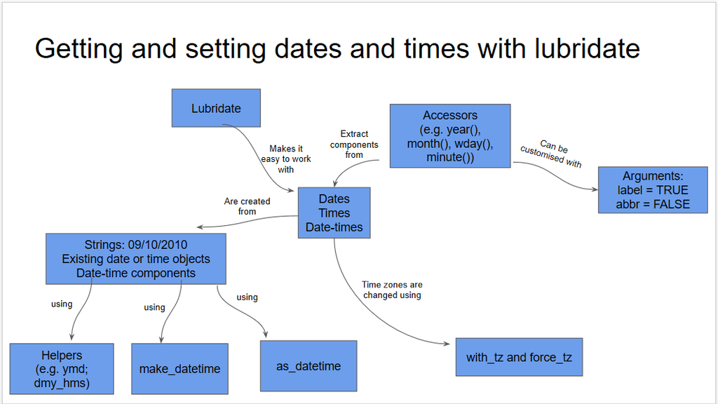

Map

## 4.13 Thinking about your projects

- What data cleaning do you need to do?
- What is the missing data like?
- What reshaping do you need to do?
- Do you work with dates?